# Analyse du méthylome des lymphomes

Étude de la signature épigénétique et caractérisation moléculaire

DU Next Generation Sequencing - Université Paris Cité

2026-10-05

# 1 Ressources et support

## 1.1 📚 Documentation

- **ComplexHeatmap** : https://jokergoo.github.io/ComplexHeatmap-reference/book/
- **ggplot2** : https://ggplot2.tidyverse.org/
- **ACP en R** : https://www.datacamp.com/tutorial/pca-analysis-r

## 1.2 💾 Instructions de reproduction

Pour reproduire cette analyse :

1. **Télécharger le fichier `.Rmd`** (bouton “Code” en haut à droite)
2. **Préparer les données** :
   - `Fichier_Bvaleur_50K.csv` : matrice de β-values
   - `Fichier_annotation.csv` : annotations cliniques
3. **Modifier le répertoire de travail** (ligne 20 du fichier .Rmd)
4. **Exécuter l’analyse** :
   - Option 1 : Cliquer sur “Knit” pour générer le rapport HTML
   - Option 2 : Exécuter chunk par chunk pour exploration interactive

**Prérequis techniques :**

- R version ≥ 4.0.0
- RStudio (recommandé)
- Connexion Internet (pour installation packages)
- Mémoire RAM ≥ 4 Go

## 1.3 🆘 Dépannage

| Problème | Solution |
| --- | --- |
| Erreur d’installation de packages | Vérifier connexion Internet, mettre à jour R/RStudio |
| “Fichier non trouvé” | Vérifier le répertoire de travail avec `getwd()` |
| Erreur de mémoire | Réduire le nombre de CpG analysés (ex: top 500 au lieu de 1000) |
| Graphiques illisibles | Augmenter les dimensions des figures dans les chunks |

# 2 Contexte et objectifs

**Objectif du TP**

Ce travail pratique a pour but d’analyser le profil de méthylation de l’ADN dans une cohorte de 16 échantillons de lymphomes. L’analyse épigénétique permet de :

- Identifier les profils de méthylation différentiels entre échantillons
- Caractériser la variabilité épigénétique inter-échantillons
- Relier les signatures de méthylation aux caractéristiques cliniques
- Découvrir des sous-groupes moléculaires par clustering non supervisé

**Cohorte :** 16 échantillons de lymphomes  
**Technologie :** Analyse de méthylation de l’ADN (β-values sur ~50 000 sites CpG)  
**Analyses :** Heatmap hiérarchique et Analyse en Composantes Principales (ACP)

**Contexte biologique :** Les lymphomes sont des cancers du système lymphatique caractérisés par une grande hétérogénéité moléculaire. L’analyse du méthylome permet d’identifier des sous-groupes de patients présentant des profils épigénétiques distincts, avec des implications pronostiques et thérapeutiques potentielles.

# 3 Configuration de l’environnement

## 3.1 Définition du répertoire de travail

```r
# Création de l'arborescence (si nécessaire)
dir.create("FIGURES", showWarnings = FALSE)
dir.create("RESULTS", showWarnings = FALSE)

cat(sprintf("✓ Répertoire de travail : %s
✓ Arborescence vérifiée : FIGURES/, RESULTS/\n", getwd()))
```

```
## ✓ Répertoire de travail : /home/antoine-qb-pasmant/Bureau/ANTOINE_THESE/PASMANT_ANTOINE/DU_2026_NGS_R_PROGRAM/LYMPHOMES
## ✓ Arborescence vérifiée : FIGURES/, RESULTS/
```

**Organisation du projet :**  
- Fichiers de données dans le répertoire principal - `FIGURES/` pour les visualisations - `RESULTS/` pour les exports de données

## 3.2 Installation et chargement des packages

```r
# Fonction utilitaire pour installer/charger les packages
load_package <- function(pkg) {
  if (!require(pkg, character.only = TRUE, quietly = TRUE)) {
    install.packages(pkg, dependencies = TRUE, repos = "https://cran.r-project.org")
    library(pkg, character.only = TRUE)
  }
}

# Packages CRAN
cran_packages <- c("ggplot2", "dplyr", "tidyr", "tidyverse", "data.table",
                   "RColorBrewer", "grid", "ggrepel", "tibble")
invisible(sapply(cran_packages, load_package))

# Packages Bioconductor
if (!requireNamespace("BiocManager", quietly = TRUE)) {
  install.packages("BiocManager", repos = "https://cran.r-project.org")
}

bioc_packages <- c("ComplexHeatmap", "circlize")
for (pkg in bioc_packages) {
  if (!require(pkg, character.only = TRUE, quietly = TRUE)) {
    BiocManager::install(pkg, ask = FALSE, update = FALSE)
    library(pkg, character.only = TRUE)
  }
}

cat("✓ Environnement R configuré avec succès\n")
```

```
## ✓ Environnement R configuré avec succès
```

# 4 Importation des données

## 4.1 Vérification et chargement des fichiers

```r
# Vérification de la présence des fichiers
fichiers_requis <- c("Fichier_Bvaleur_50K.csv", "Fichier_annotation.csv")
statut_fichiers <- file.exists(fichiers_requis)

if (!all(statut_fichiers)) {
  cat("✗ Fichiers manquants :\n")
  print(fichiers_requis[!statut_fichiers])
  stop("Veuillez placer tous les fichiers requis dans le répertoire de travail")
}

# Chargement du fichier de β-values
data <- read.csv("Fichier_Bvaleur_50K.csv", header = TRUE, sep = ",")

# Chargement du fichier d'annotations cliniques
annotation <- read.csv("Fichier_annotation.csv", header = TRUE, sep = ";")

cat(sprintf("✓ Données importées avec succès
  • Matrice de méthylation : %d sites CpG × %d échantillons
  • Annotations cliniques : %d échantillons × %d variables\n",
  nrow(data), ncol(data) - 1,
  nrow(annotation), ncol(annotation)))
```

```
## ✓ Données importées avec succès
##   • Matrice de méthylation : 50000 sites CpG × 16 échantillons
##   • Annotations cliniques : 16 échantillons × 8 variables
```

## 4.2 Exploration des données

```r
cat("═══════════════════════════════════════════════════════════\n")
```

```
## ═══════════════════════════════════════════════════════════
```

```r
cat("              APERÇU DES DONNÉES DE MÉTHYLATION            \n")
```

```
##               APERÇU DES DONNÉES DE MÉTHYLATION
```

```r
cat("═══════════════════════════════════════════════════════════\n\n")
```

```
## ═══════════════════════════════════════════════════════════
```

```r
cat("Premières lignes de la matrice de méthylation :\n")
```

```
## Premières lignes de la matrice de méthylation :
```

```r
print(head(data, 3))
```

```
##              Name         S1         S2         S3         S4         S5
## 1 cg25277809_BC21 0.06130993 0.64058938 0.03665807 0.35958673 0.58521582
## 2 cg21046355_BC11 0.05717937 0.07003532 0.08893497 0.07562048 0.08287296
## 3 cg02433135_TC21 0.77552447 0.54074466 0.36538083 0.70186606 0.63330210
##           S6         S7        S8         S9        S10        S11        S12
## 1 0.15023828 0.40142258 0.3077781 0.09149318 0.05487731 0.87557536 0.62102300
## 2 0.04947646 0.06278816 0.0548188 0.05220792 0.08694589 0.09962426 0.06182388
## 3 0.63843220 0.79392602 0.9020842 0.87273595 0.41318660 0.54950870 0.64721506
##          S13        S14        S15        S16
## 1 0.49679117 0.71353911 0.62173756 0.09851054
## 2 0.06657544 0.06008661 0.07227689 0.03151755
## 3 0.58704582 0.52737482 0.62569532 0.84407924
```

```r
cat("\n\nAperçu des annotations cliniques :\n")
```

```
##
##
## Aperçu des annotations cliniques :
```

```r
print(head(annotation, 3))
```

```
##    ID Patient Sex Deceased Transformed Gene_1 Gene_2 Gene_3
## 1  S3       1   F      Yes          No    MUT    MUT     WT
## 2 S10       1   F      Yes          No    MUT    MUT    MUT
## 3  S1       2   F       No          No     WT    MUT    MUT
```

```r
cat("\n\nRésumé des variables cliniques :\n")
```

```
##
##
## Résumé des variables cliniques :
```

```r
cat(sprintf("  • Nombre de patients : %d
  • Décès observés + Transfo : %d
  • Transformations : %d\n",
  length(unique(annotation$Patient)),
  sum(annotation$Deceased == "Yes", na.rm = TRUE),
  sum(annotation$Transformed == "Yes", na.rm = TRUE)))
```

[output not shown]

**Variables cliniques :**

- **Patient** : Identifiant du patient dont provient l’échantillon
- **Deceased** : Statut vital (Yes = décédé, No = vivant)
- **Transformed** : Transformation tumorale (Yes = transformation observée, No = pas de transformation)

# 5 Analyse de variabilité épigénétique

**Principe :** Pour identifier les sites CpG les plus informatifs, nous sélectionnons les 1000 sites présentant la plus grande variabilité inter-échantillons. Ces sites hautement variables sont les plus susceptibles de capturer l’hétérogénéité biologique de la cohorte.

## 5.1 Sélection des sites CpG les plus variables

```r
# Préparation de la matrice (exclusion de la colonne "Name")
data_heat <- data %>%
  select(-Name)
data_heat <- data[,2:17]

mat <- as.matrix(data_heat)
rownames(mat) <- data$Name

# Calcul de la variance pour chaque site CpG
variances <- apply(mat, 1, var, na.rm = TRUE)
var_df <- data.frame(
  Name = rownames(mat),
  Variance = variances
)

# Tri par variance décroissante
var_df_sorted <- var_df %>% arrange(desc(Variance))

# Sélection des 1000 CpG les plus variables
top_1000_cpg <- var_df_sorted$Name[1:1000]
mat_top_1000 <- mat[top_1000_cpg, ]

cat(sprintf("✓ Sélection des sites CpG variables
  • Total de sites : %d
  • Sites sélectionnés : %d (top 1000)
  • Variance moyenne (top 1000) : %.4f
  • Variance médiane (top 1000) : %.4f\n",
  nrow(mat),
  nrow(mat_top_1000),
  mean(var_df_sorted$Variance[1:1000], na.rm = TRUE),
  median(var_df_sorted$Variance[1:1000], na.rm = TRUE)))
```

```
## ✓ Sélection des sites CpG variables
##   • Total de sites : 50000
##   • Sites sélectionnés : 1000 (top 1000)
##   • Variance moyenne (top 1000) : 0.0604
##   • Variance médiane (top 1000) : 0.0572
```

```r
# Export de la liste des CpG variables
write.csv(var_df_sorted[1:1000, ], "RESULTS/Top1000_CpG_variables.csv", row.names = FALSE)
```

**Question pour réflexion :** Pourquoi se concentrer sur les sites CpG les plus variables ? Que représentent ces sites d’un point de vue biologique ?

# 6 Heatmap hiérarchique

**Principe du clustering hiérarchique :**

Le clustering hiérarchique regroupe les échantillons (colonnes) et les CpG (lignes) selon leur similarité. La méthode de Ward minimise la variance intra-groupe, créant des clusters homogènes. Les dendrogrammes permettent de visualiser les relations hiérarchiques entre échantillons.

## 6.1 Heatmap simple (sans annotations)

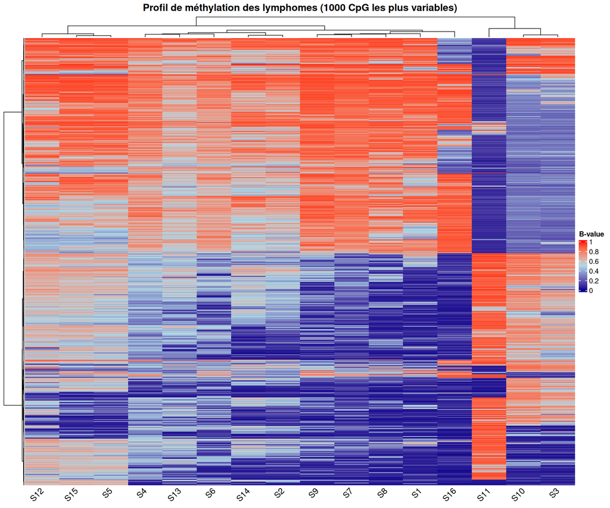

```r
# Définition de la palette de couleurs
col_fun <- colorRamp2(c(0, 0.5, 1), c("darkblue", "lightblue", "red"))

# Création de la heatmap
hm_simple <- Heatmap(
  mat_top_1000,
  name = "β-value",
  col = col_fun,
  clustering_method_rows = "ward.D",
  clustering_method_columns = "ward.D",
  show_row_names = FALSE,
  show_column_names = TRUE,
  column_title = "Profil de méthylation des lymphomes (1000 CpG les plus variables)",
  column_title_gp = gpar(fontsize = 14, fontface = "bold"),
  column_names_rot = 45,
  heatmap_legend_param = list(
    title = "B-value",
    at = seq(0, 1, by = 0.2),
    legend_direction = "vertical"
  )
)

draw(hm_simple)
```

```r
# Sauvegarde
pdf("FIGURES/Heatmap_Lymphomes_Simple.pdf", width = 12, height = 10)
draw(hm_simple)
dev.off()
```

```r
cat("✓ Heatmap simple générée : FIGURES/Heatmap_Lymphomes_Simple.pdf\n")
```

```
## ✓ Heatmap simple générée : FIGURES/Heatmap_Lymphomes_Simple.pdf
```

**Interprétation :** La heatmap révèle la structure hiérarchique des échantillons basée sur leur profil de méthylation. Les échantillons qui se regroupent partagent des patterns épigénétiques similaires. Les zones rouges indiquent une hyperméthylation (β-value proche de 1), tandis que les zones bleues indiquent une hypométhylation (β-value proche de 0).

## 6.2 Préparation des annotations cliniques

```r
# Préparation du dataframe d'annotations
anno_col <- annotation %>%
  select(ID, Patient, Deceased, Transformed, Gene_1) %>%
  as.data.frame()

# Alignement des annotations avec l'ordre des colonnes de la matrice
anno_col <- anno_col[match(colnames(mat_top_1000), anno_col$ID), ]
rownames(anno_col) <- anno_col$ID

# Définition des palettes de couleurs pour les annotations
col_list <- list(
  Patient = setNames(
    RColorBrewer::brewer.pal(length(unique(anno_col$Patient)), "Set1"),
    unique(anno_col$Patient)
  ),
  Deceased = c(Yes = "#170F00", No = "#ECEBF2"),
  Transformed = c(Yes = "#C740F5", No = "#ECEBF2"),
  Gene_1 = c(MUT = "#F55D22", doubt = "grey", WT = "blue")
)

cat(sprintf("✓ Annotations préparées
  • Patients uniques : %d
  • Échantillons décédés : %d / %d
  • Échantillons transformés : %d / %d\n",
  length(unique(anno_col$Patient)),
  sum(anno_col$Deceased == "Yes", na.rm = TRUE), nrow(anno_col),
  sum(anno_col$Transformed == "Yes", na.rm = TRUE), nrow(anno_col)))
```

```
## ✓ Annotations préparées
##   • Patients uniques : 8
##   • Échantillons décédés : 6 / 16
##   • Échantillons transformés : 3 / 16
```

## 6.3 Heatmap annotée

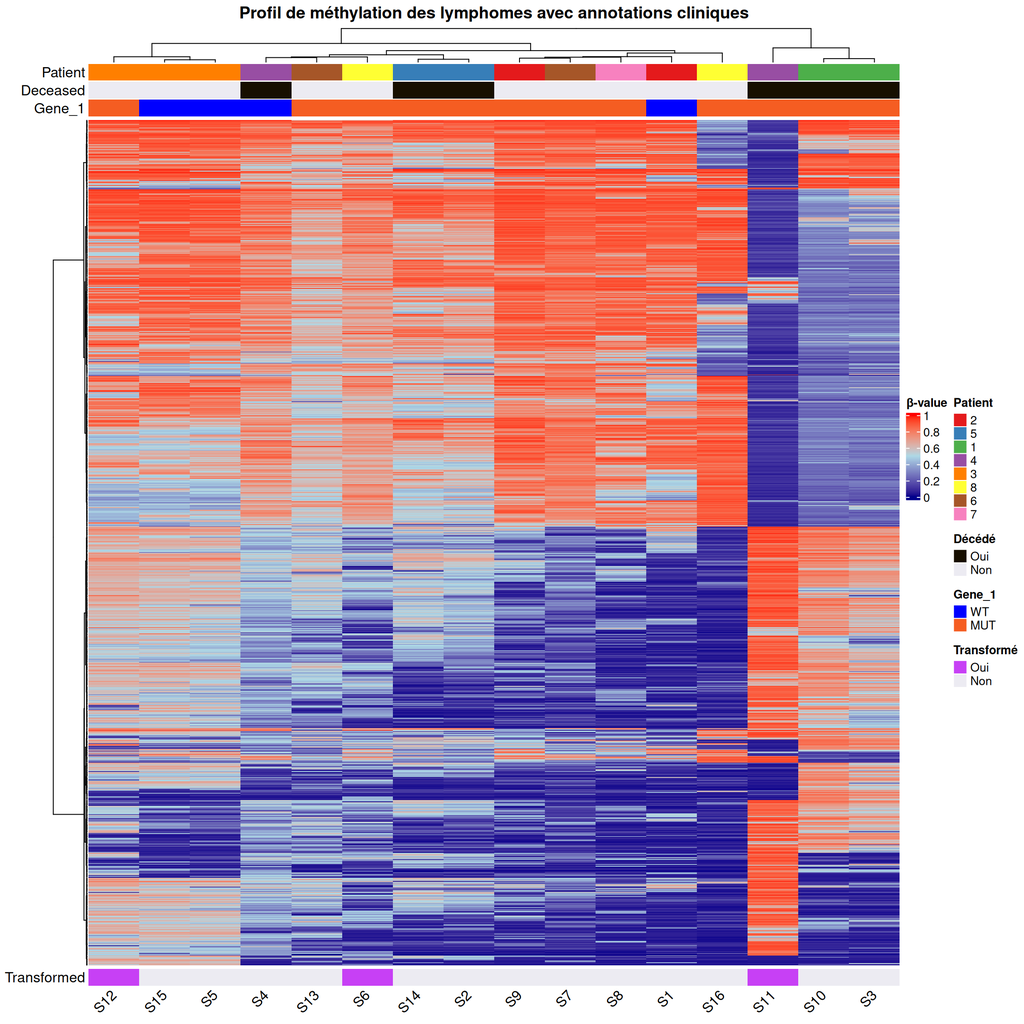

```r
# Création des annotations combinées
Top_annotation <- HeatmapAnnotation(
  Patient = anno_col$Patient,
  Deceased = anno_col$Deceased,
  Gene_1 = anno_col$Gene_1,
  col = list(
    Patient = col_list$Patient,
    Deceased = col_list$Deceased,
    Gene_1 = col_list$Gene_1
  ),
  annotation_legend_param = list(
    Patient = list(
      title = "Patient",
      at = unique(anno_col$Patient),
      labels = unique(anno_col$Patient)
    ),
    Deceased = list(
      title = "Décédé",
      at = c("Yes", "No"),
      labels = c("Oui", "Non")
    ),
     Gene_1 = list(
      title = "Gene_1",
      at = unique(anno_col$Gene_1),
      labels = unique(anno_col$Gene_1)
    )
  ),
  border = FALSE,
  annotation_name_side = "left"
)

Bottom_annotation <- HeatmapAnnotation(
  Transformed = anno_col$Transformed,
  col = list(Transformed = col_list$Transformed),
  annotation_legend_param = list(
    Transformed = list(
      title = "Transformé",
      at = c("Yes", "No"),
      labels = c("Oui", "Non")
    )
  ),
  border = FALSE,
  annotation_name_side = "left"
)

# Création de la heatmap annotée
hm_annotated <- Heatmap(
  mat_top_1000,
  name = "β-value",
  col = col_fun,
  clustering_method_rows = "ward.D",
  clustering_method_columns = "ward.D",
  show_row_names = FALSE,
  show_column_names = TRUE,
  column_title = "Profil de méthylation des lymphomes avec annotations cliniques",
  column_title_gp = gpar(fontsize = 14, fontface = "bold"),
  column_names_rot = 45,
  top_annotation = Top_annotation,
  bottom_annotation = Bottom_annotation,
  heatmap_legend_param = list(
    title = "β-value",
    at = seq(0, 1, by = 0.2),
    legend_direction = "vertical"
  )
)

draw(hm_annotated)
```

```r
# Sauvegarde
pdf("FIGURES/Heatmap_Lymphomes_Annote_2.pdf", width = 12, height = 12)
draw(hm_annotated)
dev.off()
```

```r
cat("✓ Heatmap annotée générée : FIGURES/Heatmap_Lymphomes_Annotee.pdf\n")
```

[output not shown]

**Interprétation clinique :**

Les annotations permettent de visualiser les associations potentielles entre :

- **Profils de méthylation** et **statut vital** (Deceased)
- **Profils de méthylation** et **transformation tumorale** (Transformed)
- **Regroupements d’échantillons** du même patient

Observez si les échantillons provenant du même patient se regroupent ensemble, ce qui suggérerait une signature épigénétique patient-spécifique conservée.

**Questions pour l’analyse :**

1. Identifiez-vous des clusters d’échantillons distincts ?
2. Les échantillons “Transformed = Yes” se regroupent-ils ensemble ?
3. Y a-t-il une association visuelle entre le statut “Deceased” et un profil de méthylation particulier ?
4. Les échantillons d’un même patient présentent-ils des profils similaires ?

# 7 Analyse en Composantes Principales (ACP)

**Principe de l’ACP :**

## 7.1 Calcul de l’ACP

```r
# Préparation des données pour l'ACP
data_heat <- data %>% select(-Name)

# Calcul de l'ACP (transposition pour avoir échantillons en lignes)
data_PCA <- prcomp(t(data_heat), scale. = TRUE)

# Calcul de la variance expliquée par chaque composante
variance <- data_PCA$sdev^2
percent <- round(variance / sum(variance) * 100, 1)

cat(sprintf("✓ ACP calculée
  • Variance expliquée par PC1 : %.1f%%
  • Variance expliquée par PC3 : %.1f%%
  • Variance cumulée (PC1 + PC3) : %.1f%%\n",
  percent[1], percent[2], sum(percent[1:2])))
```

[output not shown]

```r
# Extraction des 10 premières composantes
cat("\nVariance expliquée par les 10 premières composantes :\n")
```

```
##
## Variance expliquée par les 10 premières composantes :
```

```r
variance_table <- data.frame(
  Composante = paste0("PC", 1:10),
  Variance = percent[1:10],
  Variance_cumulee = cumsum(percent[1:10])
)
print(variance_table)
```

```
##    Composante Variance Variance_cumulee
## 1         PC1     28.1             28.1
## 2         PC2     16.2             44.3
## 3         PC3     10.5             54.8
## 4         PC4      8.1             62.9
## 5         PC5      6.3             69.2
## 6         PC6      4.6             73.8
## 7         PC7      4.2             78.0
## 8         PC8      3.9             81.9
## 9         PC9      3.7             85.6
## 10       PC10      3.5             89.1
```

```r
# Export du tableau
write.csv(variance_table, "RESULTS/Variance_Composantes_Principales.csv", row.names = FALSE)
```

## 7.2 Visualisation de l’ACP

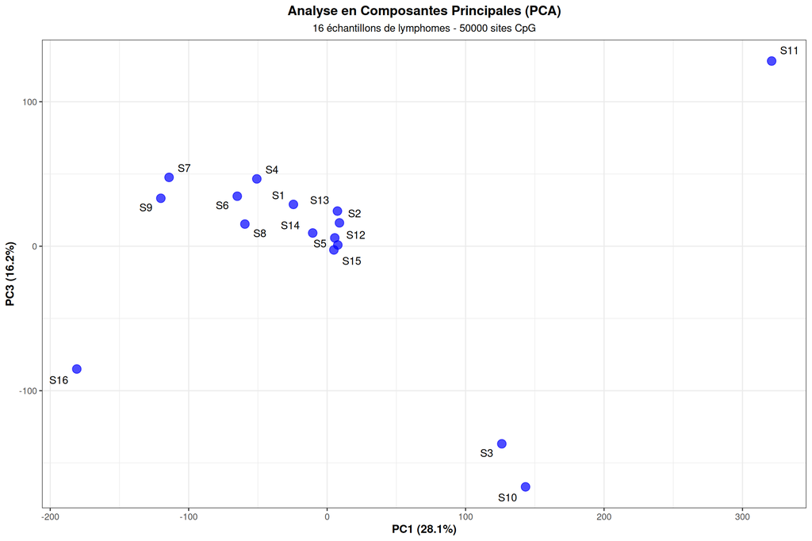

```r
# Préparation du dataframe pour ggplot
dataframe_PCA <- as.data.frame(data_PCA$x)
dataframe_PCA$Sample <- rownames(dataframe_PCA)

# Fusion avec les annotations cliniques
dataframe_PCA <- dataframe_PCA %>%
  left_join(annotation, by = c("Sample" = "ID"))

# Conversion des variables en facteurs pour les graphiques
dataframe_PCA$Patient <- as.factor(dataframe_PCA$Patient)
dataframe_PCA$Deceased <- as.factor(dataframe_PCA$Deceased)
dataframe_PCA$Transformed <- as.factor(dataframe_PCA$Transformed)

# Graphique PCA basique
p_pca_basic <- ggplot(dataframe_PCA, aes(x = PC1, y = PC3)) +
  geom_point(color = "blue", size = 4, alpha = 0.7) +
  geom_text_repel(
    aes(label = Sample),
    size = 4,
    color = "black",
    box.padding = 0.5,
    point.padding = 0.5,
    segment.color = "grey50",
    max.overlaps = Inf
  ) +
  labs(
    title = "Analyse en Composantes Principales (PCA)",
    subtitle = sprintf("16 échantillons de lymphomes - %d sites CpG", nrow(data)),
    x = paste0("PC1 (", percent[1], "%)"),
    y = paste0("PC3 (", percent[2], "%)")
  ) +
  theme_bw(base_size = 12) +
  theme(
    plot.title = element_text(hjust = 0.5, face = "bold", size = 14),
    plot.subtitle = element_text(hjust = 0.5, size = 11),
    axis.title = element_text(face = "bold")
  )

print(p_pca_basic)
```

```r
ggsave("FIGURES/PCA_Lymphomes_Basic.png", plot = p_pca_basic,
       width = 12, height = 8, dpi = 300)

cat("✓ PCA basique générée : FIGURES/PCA_Lymphomes_Basic.png\n")
```

```
## ✓ PCA basique générée : FIGURES/PCA_Lymphomes_Basic.png
```

## 7.3 PCA avec annotations cliniques

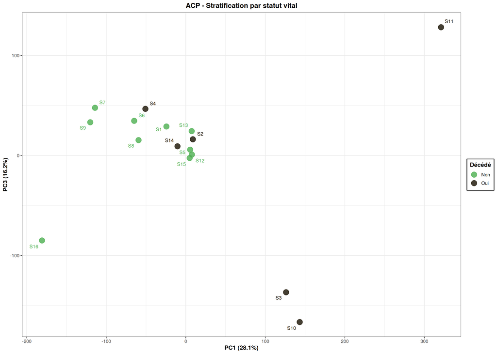

```r
# PCA colorée par statut Deceased
p_pca_deceased <- ggplot(dataframe_PCA, aes(x = PC1, y = PC3, color = Deceased)) +
  geom_point(size = 5, alpha = 0.8) +
  geom_text_repel(
    aes(label = Sample),
    size = 3.5,
    show.legend = FALSE,
    box.padding = 0.5,
    point.padding = 0.5,
    max.overlaps = Inf
  ) +
  scale_color_manual(
    values = c("Yes" = "#170F00", "No" = "#4CAF50"),
    labels = c("Yes" = "Oui", "No" = "Non"),
    name = "Décédé"
  ) +
  labs(
    title = "ACP - Stratification par statut vital",
    x = paste0("PC1 (", percent[1], "%)"),
    y = paste0("PC3 (", percent[2], "%)")
  ) +
  theme_bw(base_size = 12) +
  theme(
    plot.title = element_text(hjust = 0.5, face = "bold", size = 14),
    axis.title = element_text(face = "bold"),
    legend.position = "right",
    legend.title = element_text(face = "bold"),
    legend.background = element_rect(fill = "white", color = "black")
  )

# PCA colorée par statut Transformed
p_pca_transformed <- ggplot(dataframe_PCA, aes(x = PC1, y = PC3, color = Transformed)) +
  geom_point(size = 5, alpha = 0.8) +
  geom_text_repel(
    aes(label = Sample),
    size = 3.5,
    show.legend = FALSE,
    box.padding = 0.5,
    point.padding = 0.5,
    max.overlaps = Inf
  ) +
  scale_color_manual(
    values = c("Yes" = "#C740F5", "No" = "#81C784"),
    labels = c("Yes" = "Oui", "No" = "Non"),
    name = "Transformé"
  ) +
  labs(
    title = "ACP - Stratification par transformation tumorale",
    x = paste0("PC1 (", percent[1], "%)"),
    y = paste0("PC3 (", percent[2], "%)")
  ) +
  theme_bw(base_size = 12) +
  theme(
    plot.title = element_text(hjust = 0.5, face = "bold", size = 14),
    axis.title = element_text(face = "bold"),
    legend.position = "right",
    legend.title = element_text(face = "bold"),
    legend.background = element_rect(fill = "white", color = "black")
  )

# PCA colorée par Patient
p_pca_patient <- ggplot(dataframe_PCA, aes(x = PC1, y = PC3, color = Patient)) +
  geom_point(size = 5, alpha = 0.8) +
  geom_text_repel(
    aes(label = Sample),
    size = 3.5,
    show.legend = FALSE,
    box.padding = 0.5,
    point.padding = 0.5,
    max.overlaps = Inf
  ) +
  scale_color_brewer(palette = "Set1", name = "Patient") +
  labs(
    title = "ACP - Stratification par patient",
    x = paste0("PC1 (", percent[1], "%)"),
    y = paste0("PC3 (", percent[2], "%)")
  ) +
  theme_bw(base_size = 12) +
  theme(
    plot.title = element_text(hjust = 0.5, face = "bold", size = 14),
    axis.title = element_text(face = "bold"),
    legend.position = "right",
    legend.title = element_text(face = "bold"),
    legend.background = element_rect(fill = "white", color = "black")
  )

# Affichage et sauvegarde
print(p_pca_deceased)
```

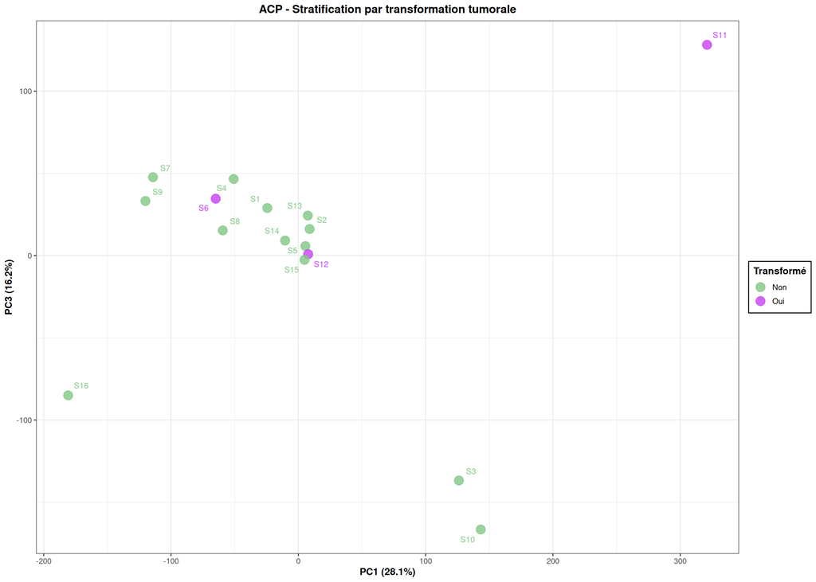

```r
print(p_pca_transformed)
```

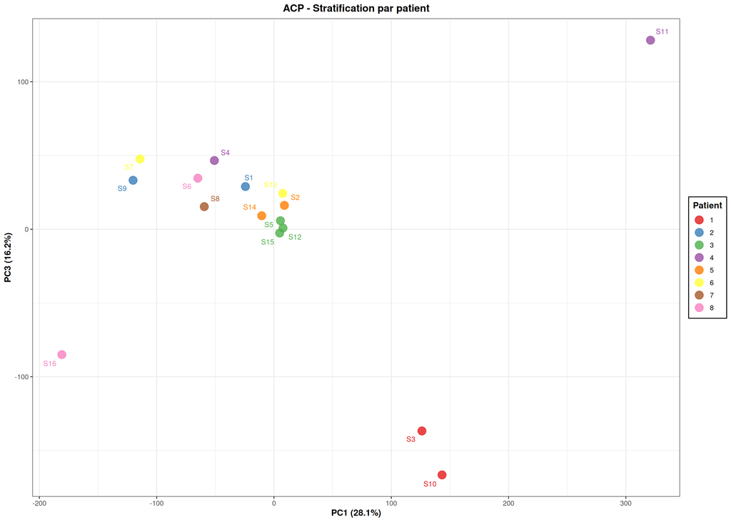

```r
print(p_pca_patient)
```

```r
ggsave("FIGURES/PCA_Lymphomes_Deceased.png", plot = p_pca_deceased,
       width = 12, height = 8, dpi = 300)
ggsave("FIGURES/PCA_Lymphomes_Transformed.png", plot = p_pca_transformed,
       width = 12, height = 8, dpi = 300)
ggsave("FIGURES/PCA_Lymphomes_Patient.png", plot = p_pca_patient,
       width = 12, height = 8, dpi = 300)

cat(sprintf("✓ PCA annotées générées :
  • FIGURES/PCA_Lymphomes_Deceased.png
  • FIGURES/PCA_Lymphomes_Transformed.png
  • FIGURES/PCA_Lymphomes_Patient.png\n"))
```

```
## ✓ PCA annotées générées :
##   • FIGURES/PCA_Lymphomes_Deceased.png
##   • FIGURES/PCA_Lymphomes_Transformed.png
##   • FIGURES/PCA_Lymphomes_Patient.png
```

**Interprétation de l’ACP :**

1. **Séparation des groupes** : Les échantillons qui se regroupent dans l’espace PC1-PC3 partagent des profils de méthylation similaires
2. **Statut vital (Deceased)** : Observez si les patients décédés (points noirs) se séparent des patients vivants (points verts) le long d’une composante principale
3. **Transformation (Transformed)** : Les échantillons transformés (violet) forment-ils un cluster distinct ?
4. **Effet patient** : Les échantillons d’un même patient (même couleur) sont-ils proches dans l’espace PCA, suggérant une signature épigénétique conservée ?

**Analyse critique :** Si PC1 + PC3 expliquent moins de 50% de la variance totale, cela indique une forte complexité épigénétique nécessitant l’examen de composantes supplémentaires.

**Questions d’analyse avancée :**

1. Quelle proportion de la variance totale est capturée par PC1 et PC3 ? Est-ce suffisant pour une interprétation biologique ?
2. Identifiez-vous des outliers (échantillons isolés) ? Que pourraient-ils représenter biologiquement ?
3. Les variables cliniques (Deceased, Transformed) expliquent-elles la séparation observée sur PC1 ou PC3 ?
4. Comparez les résultats de l’ACP avec le clustering hiérarchique de la heatmap : retrouvez-vous les mêmes groupes ?

# 8 Synthèse et export des résultats

## 8.1 Statistiques récapitulatives

```r
cat("\n═══════════════════════════════════════════════════════════\n")
```

```
##
## ═══════════════════════════════════════════════════════════
```

```r
cat("              SYNTHÈSE DE L'ANALYSE MÉTHYLOME              \n")
```

```
##               SYNTHÈSE DE L'ANALYSE MÉTHYLOME
```

```r
cat("═══════════════════════════════════════════════════════════\n\n")
```

```
## ═══════════════════════════════════════════════════════════
```

```r
cat(sprintf("DONNÉES ANALYSÉES :
  • Nombre d'échantillons : %d
  • Sites CpG totaux : %d
  • Sites CpG variables (top 1000) : %d

CARACTÉRISTIQUES CLINIQUES :
  • Patients uniques : %d

VARIANCE EXPLIQUÉE (ACP) :
  • PC1 : %.1f%%
  • PC3 : %.1f%%
  • PC1 + PC3 : %.1f%%
  • PC1 à PC10 : %.1f%%\n",
  ncol(mat), nrow(mat), length(top_1000_cpg),
  length(unique(anno_col$Patient)),
  percent[1], percent[2], sum(percent[1:2]), sum(percent[1:10])))
```

[output not shown]

```r
cat("═══════════════════════════════════════════════════════════\n")
```

```
## ═══════════════════════════════════════════════════════════
```

## 8.2 Inventaire des fichiers générés

```r
cat("\n✓ FICHIERS GÉNÉRÉS\n\nFigures (FIGURES/) :\n")
```

```
##
## ✓ FICHIERS GÉNÉRÉS
##
## Figures (FIGURES/) :
```

```r
fichiers_fig <- list.files("FIGURES", full.names = FALSE)
if (length(fichiers_fig) > 0) {
  walk(fichiers_fig, ~ cat("  •", .x, "\n"))
} else {
  cat("  (aucun fichier)\n")
}
```

```
##   • Heatmap_Lymphomes_Annote_2.pdf
##   • Heatmap_Lymphomes_Annotee.pdf
##   • Heatmap_Lymphomes_Simple.pdf
##   • PCA_Lymphomes_Basic.png
##   • PCA_Lymphomes_Deceased.png
##   • PCA_Lymphomes_Patient.png
##   • PCA_Lymphomes_Transformed.png
```

```r
cat("\nRésultats (RESULTS/) :\n")
```

```
##
## Résultats (RESULTS/) :
```

```r
fichiers_res <- list.files("RESULTS", full.names = FALSE)
if (length(fichiers_res) > 0) {
  walk(fichiers_res, ~ cat("  •", .x, "\n"))
} else {
  cat("  (aucun fichier)\n")
}
```

```
##   • Session_Info.txt
##   • Top1000_CpG_variables.csv
##   • Variance_Composantes_Principales.csv
```

## 8.3 Traçabilité

```r
writeLines(capture.output(sessionInfo()), "RESULTS/Session_Info.txt")
cat("\n✓ Informations de session enregistrées : RESULTS/Session_Info.txt
  (Versions des packages R utilisés pour la reproductibilité)\n")
```

```
##
## ✓ Informations de session enregistrées : RESULTS/Session_Info.txt
##   (Versions des packages R utilisés pour la reproductibilité)
```

# 9 Conclusion et perspectives

Cette analyse du méthylome a permis de :

1. **Caractériser la variabilité épigénétique** au sein de la cohorte de lymphomes
2. **Identifier des clusters d’échantillons** basés sur leur profil de méthylation
3. **Explorer les associations** entre signatures épigénétiques et caractéristiques cliniques
4. **Réduire la dimensionnalité** des données par ACP pour visualiser la structure globale

## 9.1 Limites de l’analyse

**Points d’attention :**

- Cette analyse est **exploratoire** et nécessite une validation statistique formelle
- Les associations observées ne démontrent pas de causalité
- La taille limitée de la cohorte (n=16) limite la puissance statistique
- L’absence de correction pour tests multiples dans cette analyse descriptive

## 9.2 Perspectives d’analyse

**Analyses complémentaires possibles :**

1. **Analyses statistiques** : Tests de significativité pour les associations cliniques, correction FDR
2. **Analyses fonctionnelles** : Annotation des CpG variables (gènes, régions régulatrices)
3. **Analyses de survie** : Courbes de Kaplan-Meier stratifiées par profil de méthylation
4. **Validation** : Cohorte indépendante pour confirmer les signatures identifiées
5. **Intégration multi-omique** : Corrélation avec transcriptome, mutations, CNV
6. **Clustering consensuel** : Définition robuste de sous-groupes moléculaires

*Document généré le 2026-10-05*  
*DU Next Generation Sequencing - Université Paris Cité*  
*Module : Analyse du Méthylome*